# Final Project

# Hide-and-SQUEAK

Liesl Eckstrom, Maia Chavez, Mary Kreklow

12/18/2023

Want to learn some RAT-ical information to RAT-tle your brain? You have come to the right place! Here, you can learn all about rats in New York City - we will keep no squeak-rets from you! If you have musophobia (a fear of rats) feel free to exit, otherwise join us on our journey as we share and interp-RAT some of our favo-RAT stats. And what better way to showcase this data than in elaboRATe shades of pink?

# Intro to The Rats Dataset

For this project, we focused on using a dataset called “Rat Sightings,” which is from NYC Open Data. This data has service requests of right sightings in New York City from 2010 to the present (Dec. 2023). It offers information about the location of the sighting, including which of New York City’s boroughs, as well as the date and time of the sighting.

We also used a dataset with weather information from NYC. This dataset was scraped from Weather Underground and includes average daily temperatures, daily high and low temperatures, as well as weather events and precipitation details for every day from 1940-2020. We used the data from 2010 to 2020, as these are the dates that overlap with our Rat Sightings dataset.

We will use these data to discover where and when rats are most abundant!

# Map

Most people are very pro-rat or anti-rat, so they would either be happy to see rats or avoid them at all costs. Because of this, one of the first things that comes to mind when you think of rats is wondering where you are most likely, or least likely, to find them. We decided that the best way to explore this further would be to look at the areas of New York City with the highest concentrations of rats. We decided to make a heat map to help visualization of the most rat-packed areas.

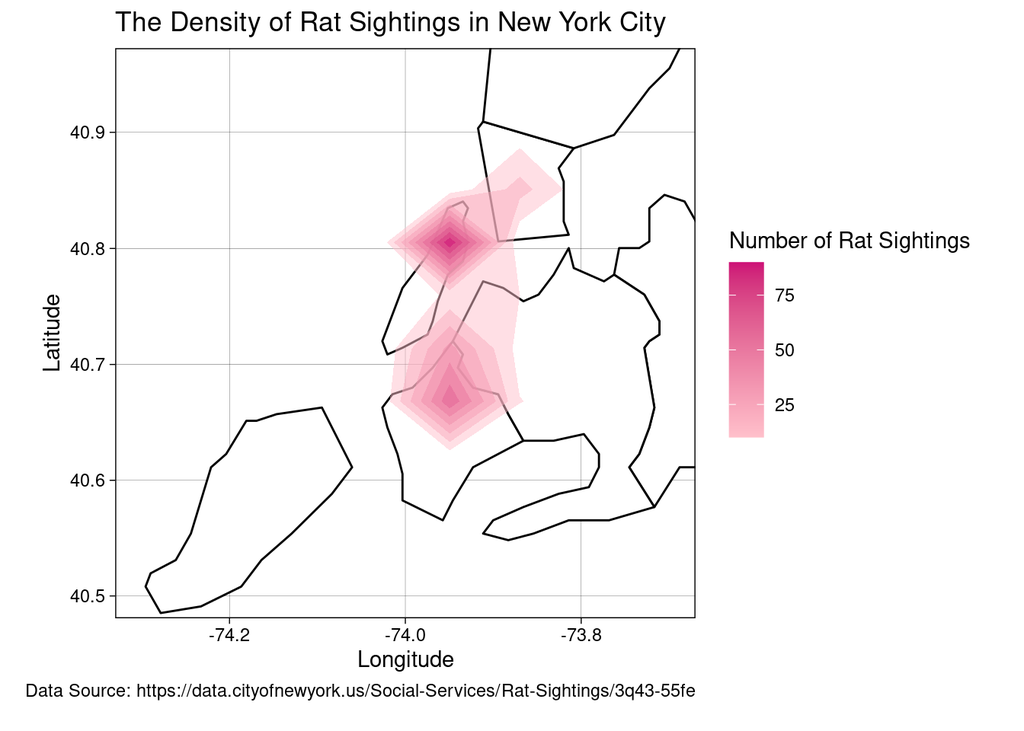

As shown, this is a heat map that shows the areas of New York City with the observations of rat sightings. We decided to use a map of the different boroughs and plot the rat sightings by their longitude and latitude. As shown by the darker shades of pink on the map, the two boroughs with the highest concentration of rat sightings are Brooklyn and Manhattan, followed by Bronx and Queens. If you are a rat-hater, we would recommend sticking close to Staten Island, where there are less rats to be found. However, if you are looking to make some rat friends (perhaps a bro-dent or two), you would probably have the best luck in Brooklyn or Manhattan.

# Most Popular Rat Locations

In order to further examine where rats are more abundant, we looked at what types of locations the rats are most commonly sighted. We split the variable Location type into seven categories: residential, other, non residential buildings, outdoor locations, vacant locations, educational locations, and food locations. We decided to use a bar graph to visualize where rats are most commonly seen.

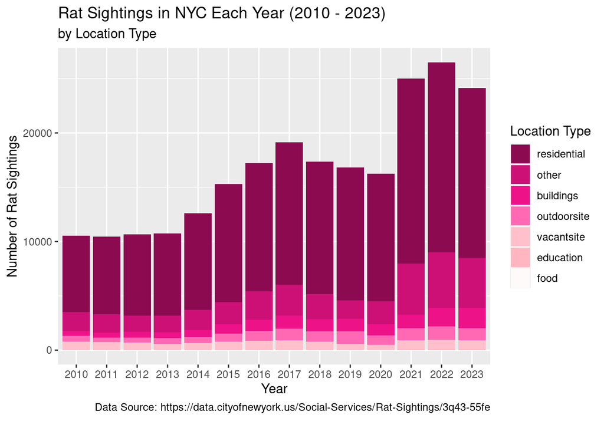

In this bar graph, you can see that most rat sightings occur in residential areas. It’s surprising that there were way more rat sightings in residential areas than there were in outdoor sites, which include places like sewers and parking lots. While this is unsettling, it’s also comforting to know that very few rat sightings occur in food locations such as grocery stores and restaurants. There also weren’t many rat sightings in educational areas. The second most common type of location to see rats was “Other”, which we weren’t given much information about in the dataset, so it is unclear where a lot of rat sightings happen. We can also see from the bar chart that rat sightings in these locations have generally gone up as the years have gone by.

# Popular Residential Streets

Now that we know that residential areas have the most rat sightings, we can determine which residential streets are most popular with rats. To this we decided to filter the data set to only include residential locations, find the five most frequent streets, and use a faceted scatterplot with the year to see how many rats visit these popular streets each year.

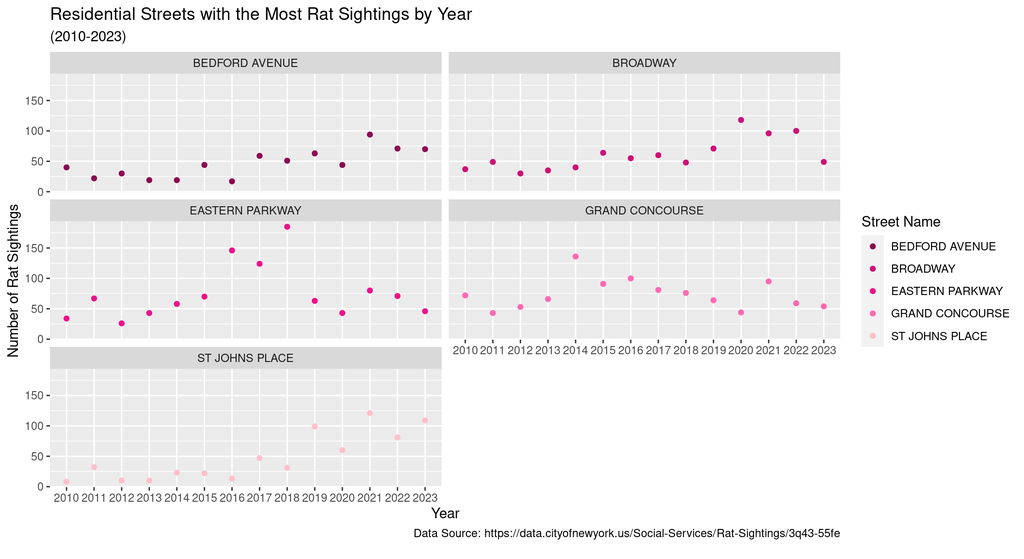

The five most popular residential streets for the rats to hang out in are Bedford Avenue, Broadway, Eastern Parkway, Grand Concourse, and St. Johns Place. So, if you are ever looking to settle down with your rat friends in New York, get a home on these streets. Some of these locations have had an increase in rat friends over the years, but others have a pretty consistent population. As you can see above, St. Johns Place, Bedford Avenue, and Broadway have grown in popularity. St. Johns Place increases a lot, while our Bedford Avenue and Broadway rats increase very slightly. Grand Concourse and Eastern Parkway have been pretty consistent with their number of rat sightings. However, Eastern Parkway did have a very large amount of rat sightings for a couple of years.

# Rat Sightings in Park Boroughs

The next variables that we looked at with this data set were park borough and month. We made a bar chart with months and rat sightings on the axes to show the spread over the months of the years and used a fill with park borough to show the spread over park borough.

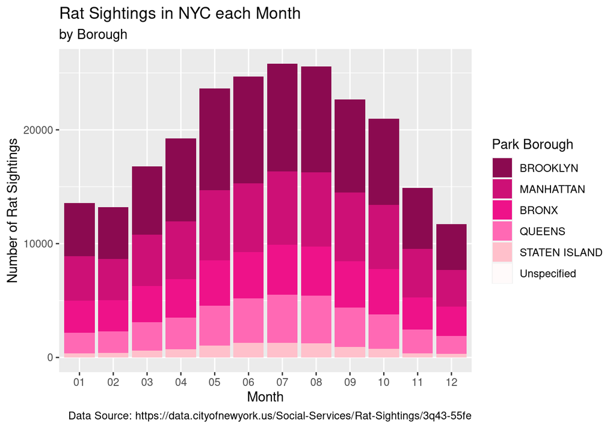

There was a significant trend for more rat sightings in the warmer months than the colder months with a peak in July and steadily decreasing both ways from the peak. We think that this could be for two different reasons, either there are more people out and about to report the rat sightings or there are more rats out and about to be spotted when it’s warmer outside. The park borough with the most amount of rat sightings is Brooklyn and the one with the least amount of sightings is Staten Island. Our hypothesis for this is that Brooklyn has the most rat sightings because it has the highest population and that Staten Island has the least amount of rat sightings for two different reasons. The reasons are that Staten Island has the smallest population and it is more separated from the rest of the New York City park boroughs.

# Rats and Weather Conditions

One of our other curiosities was if the day’s weather conditions had an effect on the number of rat sightings that were reported. Because our rats dataset didn’t include weather information, we had to add a dataset with weather data to our rats dataset. We joined the datasets together and were able to look at both weather events and daily temperatures. We chose to use the average daily temperature as well as the occurrence of weather events for this graph. We hypothesized that rats would be seen the most on warmer (70s) days with no weather events because that is the time when we most prefer to be out and about and figured the rats might agree.

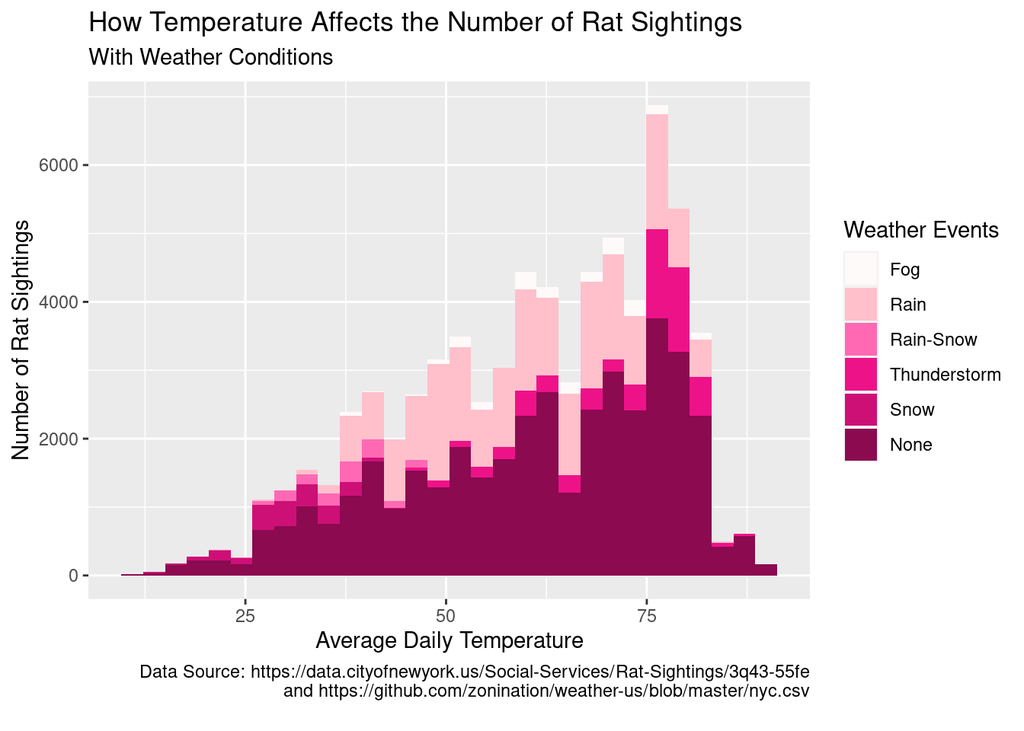

We were correct in our temperature hypothesis, as we can see that the highest number of rat observations was at temperatures in the upper 70 degrees Fahrenheit. However, we were slightly off with our observation that most of the observations would be on days with no weather events, as it appears that close to half of the observations were made on days with weather events, the main one being rain. This could be for a few reasons, including the fact that most weather events do not last an entire day. Even if a weather event was recorded for the same day as the rat sighting, that does not mean that the rat sighting happened during the weather event. Because we do not have weather observations directly associated with the rat sightings, it is impossible to truly know the distribution. Nonetheless, you do have a greater chance of seeing a rat when there is not a weather event, therefore if you want to avoid rats, you will have a better chance if you go out on miserable days full of snow, thunderstorms, and fog.

# Limitations

The largest limitation for our project is that the dataset we used for rat sightings can only track the rats that people are seeing and not all the rats in New York City, so this data is not going to be representative of all the rats in NYC.

It would also be interesting to look into how rat patterns in New York City compare to other cities, and different programs the city might have in place to control the rat population.

# Conclusion

We hope these rat graphs were not too cheesy for you. Perhaps learning about rats has made you squeak with delight! Either way, we feel that this information is seriously under-rat-ed, and would like to cong-rat-ulate you for making it through. Have a mice day!